# IRT model fitting

Norwegian CDI:WG Production

# Setup

Below are the settings for the analyses reported in this document.

```r
language <- "Norwegian"
scale <- "WG Production" # one of "WG Comprehension", "WG Production", "WG Gestures", "WS"
```

Plot titles, file names etc. are based on them.

Please make sure the subtitle of this document and the filename are consistent with these settings (language and scale). Other than that do not change the code or text in the document (unless you know what you are doing). No code modifications should be required to successfully run the code (and eventually knit the document), as long as you have the required data ready (read below).

The following libraries are loaded.

```r
library(beepr)
library(tidyverse)
library(mirt)
```

Functions from “Functions” directory are sourced. Data are expected and saved in “Data” directory.

## Data preparation

Data may be downloaded from the Wordbank database and saved locally for quicker access in the future. See and run the chunk below for that (modifying calls to `select()` if more data, demographics in particular, is needed).

```r
# Get responses and item data:
wordbankr::get_instrument_data(language, version,
                               administration_info=TRUE,
                               item_info=TRUE) %>%
     filter(is_norming) -> responses
# More item data available, if needed -- modify select():
responses %>%
     select(child_id, item_id, item_definition, english_gloss, item_kind, value) %>%
     write_csv(paste(filename_data, "responses.csv", sep="_"))

# Get demographics data:
wordbankr::get_administration_data(language, version,
                                   include_demographic_info=TRUE,
                                   include_birth_info=TRUE,
                                   include_health_conditions=TRUE,
                                   include_language_exposure=TRUE,
                                   include_study_internal_id=TRUE) %>%
     filter(is_norming) -> participants
# More demographics data available, if needed -- modify select():
participants %>%
     select(child_id, age, sex) %>%
     write_csv(paste(filename_data, "participants.csv", sep="_"))
```

There should be two *csv* files:

1. “Data/norwegian_wg_responses.csv” and
2. “Data/norwegian_wg_participants.csv”.

First one is used to extract the list of Norwegian WG Production items (with their definitions and English glosses, if available). Relevant responses are recoded as 0’s and 1’s appropriately.

Second one contains demographic data (*age* and *sex* in particular).

There are three key objects needed for all the analyses done and presented here:

1. `responses` matrix (administrations x items; 0/1)
2. `cdi` data frame (items with their definitions & glosses)
3. `scores` data frame (participant information: raw scores & demographics)

To prepare the `responses` matrix we eliminate *floor* and *ceiling* (zero variance) items.

**NB:** `Mirt` documentation suggests removing, as *floor* and *ceiling*, items with difficulties > *.95* and < *.05*. **Check and explore in the future?**

There are 2258 Norwegian WG Production administrations and 395 Norwegian WG Production items. After removing *floor* and *ceiling* items there are 2258 administrations and 395 items for IRT model fitting.

We export `scores` data frame to “Data/norwegian_wg_prod_scores.csv” to use it once we have a model.

# Number of quadrature points

## Introduction

The number of quadrature points (`quadpts` parameter in `mirt` package) is a parameter important for numerical integration used in the IRT model fitting. We know that for some of our datasets the default number results in the model not converging. Therefore with new data we used to routinely first try model fitting with an increasing number of `quadpts`, starting with the default 61, and going up by an arbitrary number of arbitrary steps. We would then compare the convergence of the model, its fit, and the parameter estimates for the first item, and choose the `quadpts` for which these statistics stabilised (roughly).

Given that model fitting is a one-off thing (we save the model for later reuse), it seems more convenient – and also beneficial in the context of cross data comparisons – to set `quadpts` reasonably high and keep it constant. The following section is totally optional.

## Model comparisons (*only if needed*)

From time to time we might want to run these comparisons. E.g., if new analyses yield results different from the old ones, or for new data, especially if the model doesn’t converge on the first try.

The `quadpts` values tested and the choice criteria are not precise but it shouldn’t matter. The greater the value the longer fitting time but greater precision. The default, historical, vector `quadpts = c(61, 151, 301, 451, 601, 751)` can be changed as required.

```r
quadpts <- quadpts_comp(responses, quadpts = c(61, 151, 301, 451, 601, 751), NCYCLES = 100000,
             output_file = paste(filename_prefix, "quadpts.RData", sep="_"))
```

Results of the above code are saved to a file (“Data/norwegian_wg_prod_quadpts.RData”), so it needs to be run only once.

The convergence status and model fits (logLik) for different values of `quadpts` (which can be printed below) are read from that file.

The same applies to parameter estimates for the first item.

## Setting

Based on the above (**or not**) we set the number of quadrature points. 600 is the current cross-data and cross-languages default.

```r
quadtp <- 600
```

# Model fitting

Our fitting the IRT model is an iterative process that involves eliminating items and refitting the model in two loops, one within the other.

1. In the “inner” loop we iteratively fit the model with 600 quadrature points, remove potential misfits (significant S-X²) and refit until we have fits for all items.
2. Then we examine *local dependency* (Cramer’s $V$) and, if there are items to remove, we go back to point 1 (this is the “outer” loop).

The “inner” loop, given its simple and easy to set criterion (significance), is fully automatic and built into a custom function from “Functions” directory. The “outer” loop is run manually. With the current criterion (Cramer’s $V$ threshold) it could be made automatic as well but, given that this approach is likely suboptimal (see below), we keep it as it is: if there are items to be removed in step 2, the code execution halts and rerunning previous chunks is suggested.

Key intermediate results are saved to files in “Data” directory with Norwegian WG Production and “outer” loop iteration number kept in filenames. If the document knits, the whole model fitting procedure has already succeeded and the summary is simply printed below.

## Step 1. Misfits removal

We repeatedly fit the IRT model using 600 quadrature points and maximally $100000$ cycles. Each time we remove items for which S-X² is significant with $p < 0.001$ and refit the model, until there are no items to remove.

## Step 2. Local dependence

We check pairwise correlations between items after taking the model (i.e., the underlying trait) into account. For each pair of residuals we calculate Cramer’s $V$, a measure of association between two dichotomous variables.

### More on the issue

What `mirt` package returns are **signed** coefficients and the sign indicates the direction of the relation. Positive relation (*local dependence*) means that two items are more related than the model predicts, i.e., are too similar or redundant. IRT assumes *local independence*: after conditioning on the latent trait $\theta$, responses are assumed to be statistically independent; or in plain English, if we know a person’s ability level, knowing their response to one item should not help us predict their response to another; *Chat GPT* assistance).

Keeping locally dependent items in the item pool may lead to a number of distortions in CAT measurement (crucially, among other, inflated $\theta$ estimates; *Chat GPT* assistance). This is why it is important to monitor this problem. As with any correlation metric however, its interpretation is always arbitrary.

So far we have simply removed all item pairs with $V > .5$. However, $.5$ might be too *high* as a threshold, potentially leaving in too many locally dependent items. At the same time, removing *both items* is obviously too harsh, reducing the item pool excessively, since the problem is the relation between them, not the items themselves.

Deciding on which item to keep is not straightforward though. The simplest option is to rely on a single statistic, e.g., *item’s fit*, but high $V$ pairs are often *gender pairs* like “mommy–daddy”, “boy–girl”, “grandpa–granny”, “his–her”: keeping only one seems somewhat questionable (this is in fact a potential guideline for future CDI development/revisions: **make such pairs single items**). Moreover, the same item may appear in a number of high $V$ pairs: it’s reasonable to remove that item, even if its fit is better than the other items’.

All the above suggests that diagnosing local dependence is a complex issue that might require careful examination and deliberate decisions, rether than a purely algorithmic procedure.

### Summary & selection

So far it seems (with various datasets) that refitting the model for a subset of items (after exclusions) doesn’t affect Cramer’s $V$ for remaining pairs, so the “outer” loop iterates twice at most (all high $V$ items are removed in the first iteration). **It might be worth exploring** but meanwhile we just summarise Cramer’s $V$ distribution after any previous exclusions.

The histogram below shows the (**signed**) Cramer’s $V$ distribution.

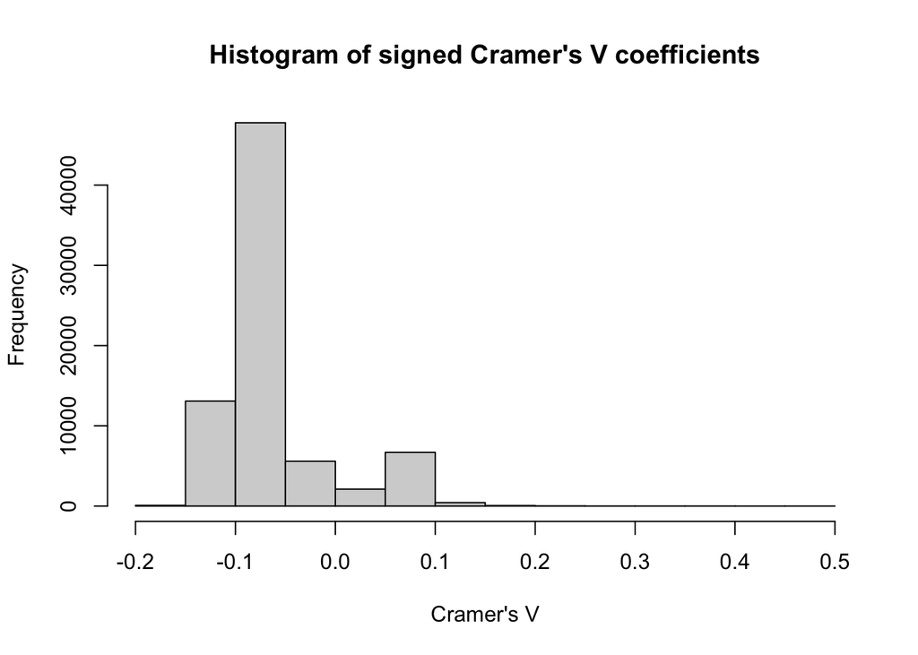

These are the descriptive statistics of the distribution.

```
##        Min.     1st Qu.      Median        Mean     3rd Qu.        Max.
## -0.17769547 -0.09385935 -0.07654024 -0.06270979 -0.05692711  0.48455021
```

To display *questionably* mutually dependent items we use $V > .3$ as the threshold. We print their definitions, English glosses, and fit statistics (S-X²).

| item_definition_1 | english_gloss_1 | item_definition_2 | english_gloss_2 | CramersV | item1_fit | item2_fit |
| --- | --- | --- | --- | --- | --- | --- |
| gutt | boy | jente | girl | 0.3952170 | 178.8868 | 161.20562 |
| morfar | grandfather | mormor | Granny | 0.4845502 | 313.2187 | 296.63288 |
| oldefar | great grandfather | oldemor | great grandmother | 0.3240835 | 148.7721 | 189.57248 |
| mamma | mommy | pappa | daddy | 0.3539467 | 49.7630 | 85.26655 |
| hans | his | hennes | her | 0.3773026 | 185.8280 | 159.12229 |
| ned | down | opp | up | 0.3058518 | 230.0814 | 234.67539 |
| nede | down | oppe | up | 0.3141635 | 157.5688 | 199.48389 |

In the same way we also print all pairs with *questionably* high negative values ($V < -.3$).

| item_definition_1 | english_gloss_1 | item_definition_2 | english_gloss_2 | CramersV | item1_fit | item2_fit |
| --- | --- | --- | --- | --- | --- | --- |

To **remove** the most highly mutually dependent items we use $V > .5$ as the threshold.

# Summary

We repeatedly fit the IRT model using 600 quadrature points and maximally $100000$ cycles.

Below is a summary of the whole iterative item removal procedure.

## *Outer loop* iteration 1

### Step 1. Misfits removal

No items removed.

### Step 2. High *local dependence* items removal

4 items removed.

| item_definition_1 | english_gloss_1 | item_definition_2 | english_gloss_2 | CramersV |
| --- | --- | --- | --- | --- |
| bestefar | grandfather | bestemor | grandmother | 0.5436774 |
| farfar | grandfather | farmor | grandmother | 0.5598755 |

## *Outer loop* iteration 2

### Step 1. Misfits removal

1 item(s) removed in 1 iteration(s).

| inner_loop | item_definition | english_gloss |
| --- | --- | --- |
| 1 | klappe kake | pat cake |

## Final model

This is the final model’s basic summary.

```
##
## Call:
## mirt(data = responses, model = 1, SE = TRUE, quadpts = quadtps,
##     technical = list(NCYCLES = NCYCLES))
##
## Full-information item factor analysis with 1 factor(s).
## Converged within 1e-04 tolerance after 1036 EM iterations.
## mirt version: 1.41
## M-step optimizer: BFGS
## EM acceleration: Ramsay
## Number of rectangular quadrature: 600
## Latent density type: Gaussian
##
## Information matrix estimated with method: Oakes
## Second-order test: model is a possible local maximum
## Condition number of information matrix =  916.8754
##
## Log-likelihood = -276212.6
## Estimated parameters: 780
## AIC = 553985.2
## BIC = 558448.5; SABIC = 555970.3
## G2 (9999999220) = 517892, p = 1
## RMSEA = 0, CFI = NaN, TLI = NaN
```